# MSU Grade Analysis

Adhi Rajaprabhakaran

9/19/2017

## Importing/Cleaning

Firstly, I just wanna give huge, huge props to Colin Dillinger who is the one who submitted the FOIA and scraped all the data into the excel format that we’re about to download. It’s just that excel isn’t good enough for me :).

Let’s download and check out the dataset as it is.

```
## Response [https://msugrades.github.io/excel/Grades.xlsx]
##   Date: 2018-02-24 06:00
##   Status: 200
##   Content-Type: application/vnd.openxmlformats-officedocument.spreadsheetml.sheet
##   Size: 9.29 MB
## <ON DISK>  /var/folders/ny/k7qcscqs25gbyftj9zywrh1r0000gn/T//RtmpfhaTQO/file1574d1a9385b9.xlsx
```

```r
glimpse(grades)
```

```
## Observations: 46,010
## Variables: 43
## $ Term Code         <chr> "FS17", "FS17", "FS17", "FS17", "FS17", "FS1...
## $ Sortable Term     <chr> "2017-3", "2017-3", "2017-3", "2017-3", "201...
## $ Subject Code      <chr> "AAAS", "AAAS", "AAAS", "ABM", "ABM", "ABM",...
## $ Course Code       <chr> "100", "300", "999", "100", "100", "130", "1...
## $ Course Title      <chr> "Race and Community", "Survey in Africana", ...
## $ Instructor        <chr> "XHERCIS MENDEZ", "GLENN A CHAMBERS JR", "NU...
## $ Total Grades      <dbl> 40, 12, 0, 134, 103, 154, 76, 28, 83, 73, 13...
## $ Total Law Grades  <dbl> 0, 0, 0, 0, 0, 0, 0, 0, 0, 0, 0, 0, 0, 0, 0,...
## $ Average Grade Raw <dbl> 3.600000, 3.208333, NA, 2.809701, 2.325243, ...
## $ Average Grade     <chr> "3.6", "3.2083333333333335", "N/A", "2.80970...
## $ 4                 <dbl> 24, 4, 0, 31, 9, 20, 7, 4, 39, 8, 22, 6, 7, ...
## $ 3.5               <dbl> 6, 2, 0, 31, 14, 22, 9, 7, 23, 25, 25, 9, 4,...
## $ 3                 <dbl> 6, 3, 0, 19, 17, 32, 14, 7, 5, 15, 33, 6, 15...
```

[output cut: 30 more lines]

The FOIA office was kind enough to calculate mean grades for us, but we will calculate it ourselves after tidying the data a bit.

There are two grading scales in this dataset - the point scale and the letter scale. The vast majority of MSU students are graded on the point scale, 1.0-4.0. The one exception is the law school, where a more traditional letter scale is used. Just to make sure:

```r
grades %>%
  filter(`A` > 0) %>%
  select(`Subject Code`) %>%
  unique()
```

```
## # A tibble: 1 x 1
##   `Subject Code`
##            <chr>
## 1            LAW
```

These data are interesting in their own right, but let’s just look at grades that abide by the regular system.

```r
grades <- grades %>%
  filter(`Subject Code` != 'LAW') %>%
  select( -8, -(26:38)) # these columns are the law school grades, we don't want them

glimpse(grades)
```

```
## Observations: 45,023
## Variables: 29
## $ Term Code         <chr> "FS17", "FS17", "FS17", "FS17", "FS17", "FS1...
## $ Sortable Term     <chr> "2017-3", "2017-3", "2017-3", "2017-3", "201...
## $ Subject Code      <chr> "AAAS", "AAAS", "AAAS", "ABM", "ABM", "ABM",...
## $ Course Code       <chr> "100", "300", "999", "100", "100", "130", "1...
## $ Course Title      <chr> "Race and Community", "Survey in Africana", ...
## $ Instructor        <chr> "XHERCIS MENDEZ", "GLENN A CHAMBERS JR", "NU...
## $ Total Grades      <dbl> 40, 12, 0, 134, 103, 154, 76, 28, 83, 73, 13...
## $ Average Grade Raw <dbl> 3.600000, 3.208333, NA, 2.809701, 2.325243, ...
## $ Average Grade     <chr> "3.6", "3.2083333333333335", "N/A", "2.80970...
## $ 4                 <dbl> 24, 4, 0, 31, 9, 20, 7, 4, 39, 8, 22, 6, 7, ...
## $ 3.5               <dbl> 6, 2, 0, 31, 14, 22, 9, 7, 23, 25, 25, 9, 4,...
## $ 3                 <dbl> 6, 3, 0, 19, 17, 32, 14, 7, 5, 15, 33, 6, 15...
## $ 2.5               <dbl> 2, 2, 0, 16, 21, 24, 10, 7, 6, 8, 22, 9, 3, ...
```

[output cut: 16 more lines]

The dataset has some annoying column names, with spaces and capital letters. I heard what’s cool in the tidyverse is all lowercase and underscores in lieu of spaces.

```r
names(grades) <- names(grades) %>%
  tolower() %>%
  gsub(" ", "_", .)
names(grades)
```

```
##  [1] "term_code"         "sortable_term"     "subject_code"
##  [4] "course_code"       "course_title"      "instructor"
##  [7] "total_grades"      "average_grade_raw" "average_grade"
## [10] "4"                 "3.5"               "3"
## [13] "2.5"               "2"                 "1.5"
## [16] "1"                 "0"                 "incomplete"
## [19] "withdrawn"         "pass"              "no_grade"
## [22] "deferred"          "unfinished_work"   "visitor"
## [25] "auditor"           "extension"         "conditional_pass"
## [28] "no_grade_reported" "blank"
```

Now, as a devotee of the tidyverse (Praise Be Upon Hadley), I have to convert this data to tidy format, even if I get a dataframe with unwieldly dimensions.

In the process, I drop all of the columns that don’t give us grade information. I’m sure there are interesting questions to ask regarding incompletes and auditors, but that’s for another day as we’re trying to establish a mile-high look at grading practices most relevant to studennts.

```r
tidy_grades <- grades %>%
  select(term_code:instructor, `4`:`0`) %>%
  gather(grade, quantity, -(term_code:instructor)) %>%
  mutate(grade = as.numeric(grade),
         course_code = as.numeric(course_code)) #numerics are easier to sort by

glimpse(tidy_grades)
```

```
## Observations: 360,184
## Variables: 8
## $ term_code     <chr> "FS17", "FS17", "FS17", "FS17", "FS17", "FS17", ...
## $ sortable_term <chr> "2017-3", "2017-3", "2017-3", "2017-3", "2017-3"...
## $ subject_code  <chr> "AAAS", "AAAS", "AAAS", "ABM", "ABM", "ABM", "AB...
## $ course_code   <dbl> 100, 300, 999, 100, 100, 130, 130, 130, 203, 222...
## $ course_title  <chr> "Race and Community", "Survey in Africana", "Doc...
## $ instructor    <chr> "XHERCIS MENDEZ", "GLENN A CHAMBERS JR", "NULL",...
## $ grade         <dbl> 4, 4, 4, 4, 4, 4, 4, 4, 4, 4, 4, 4, 4, 4, 4, 4, ...
## $ quantity      <dbl> 24, 4, 0, 31, 9, 20, 7, 4, 39, 8, 22, 6, 7, 57, ...
```

Now we have a tidy dataset that is a whopping 360k rows and 8 columns. Every row is a professor-class-semester-grade combination, and the observation is the quantity of the grade awarded.

The one hold up is that there are nearly 200 unique subject codes and we don’t know all of them. To find out, let’s join that in really quick by scraping it off MSU’s class schedule site.

```r
library("rvest")
library("stringr")

codes_and_names <- read_html("https://schedule.msu.edu/") %>%
  #the following is the html tag to access a dropdown with all majors
  html_nodes("#MainContent_SrearchUC_ddlSubject option") %>%
  html_text() %>%
  str_split(":", simplify = TRUE) %>%
  as_tibble() %>%
  rename(subject_code = V1,
         subject_name = V2)

codes_and_names
```

```
## # A tibble: 236 x 2
##    subject_code                    subject_name
##           <chr>                           <chr>
##  1         AAAS  African American & Afr Studies
##  2          AAE       Advanced Academic English
##  3          ABM         Agribusiness Management
##  4          ACC                      Accounting
##  5          ACM    Arts and Cultural Management
##  6          ACR       Comm Ag Rec & Res Studies
##  7          ADV                     Advertising
##  8           AE        Agricultural Engineering
##  9          AEC          Agricultural Economics
## 10          AEE               ANR Edu & Com Sys
## # ... with 226 more rows
```

```r
tidy_grades <- tidy_grades %>%
  left_join(codes_and_names) %>%
  #reordering the columns
  select(term_code:subject_code, subject_name, course_code:quantity)

glimpse(tidy_grades)
```

```
## Observations: 360,184
## Variables: 9
## $ term_code     <chr> "FS17", "FS17", "FS17", "FS17", "FS17", "FS17", ...
## $ sortable_term <chr> "2017-3", "2017-3", "2017-3", "2017-3", "2017-3"...
## $ subject_code  <chr> "AAAS", "AAAS", "AAAS", "ABM", "ABM", "ABM", "AB...
## $ subject_name  <chr> " African American & Afr Studies", " African Ame...
## $ course_code   <dbl> 100, 300, 999, 100, 100, 130, 130, 130, 203, 222...
## $ course_title  <chr> "Race and Community", "Survey in Africana", "Doc...
## $ instructor    <chr> "XHERCIS MENDEZ", "GLENN A CHAMBERS JR", "NULL",...
## $ grade         <dbl> 4, 4, 4, 4, 4, 4, 4, 4, 4, 4, 4, 4, 4, 4, 4, 4, ...
## $ quantity      <dbl> 24, 4, 0, 31, 9, 20, 7, 4, 39, 8, 22, 6, 7, 57, ...
```

Now, let’s get to the good parts.

## Which majors are the easiest and hardest?

This is naturally the first question that a student would be interested in knowing.

Due the format of the grade information, we have to get a bit creative with calculating the summary stats of each subject by using `sum` and `rep` for the mean and median grade respsectively.

```r
gpas_by_subject <- tidy_grades %>%
  group_by(subject_code, subject_name) %>%
  #reasonable amount of students since 2011 to lose outliers
  #filter(sum(quantity) > 5000) %>%
  summarise(mean_grade = sum(grade*quantity)/sum(quantity),
            median_grade = median(rep(grade, quantity), na.rm = TRUE),
            freq = sum(quantity))
            #this will be the number of grades awarded in total sicne 2017

gpas_by_subject
```

```
## # A tibble: 186 x 5
## # Groups:   subject_code [?]
##    subject_code                    subject_name mean_grade median_grade
##           <chr>                           <chr>      <dbl>        <dbl>
##  1         AAAS  African American & Afr Studies   3.446809          3.5
##  2          ABM         Agribusiness Management   2.924419          3.0
##  3          ACC                      Accounting   3.009304          3.0
##  4          ACM    Arts and Cultural Management   3.530822          4.0
##  5          ACR       Comm Ag Rec & Res Studies   3.540628          4.0
##  6          ADV                     Advertising   3.320687          3.5
##  7           AE        Agricultural Engineering   2.981266          3.5
##  8          AEC          Agricultural Economics   3.558370          3.5
##  9         AESC    Applied Engineering Sciences   3.546207          3.5
## 10          AFR               African Languages   3.655738          4.0
## # ... with 176 more rows, and 1 more variables: freq <dbl>
```

Easiest majors:

```r
gpas_by_subject %>%
  arrange(desc(mean_grade))
```

```
## # A tibble: 186 x 5
## # Groups:   subject_code [186]
##    subject_code                    subject_name mean_grade median_grade
##           <chr>                           <chr>      <dbl>        <dbl>
##  1          OST            Osteopathic Medicine   3.975904            4
##  2           IM               Internal Medicine   3.940000            4
##  3          GEN                        Genetics   3.916667            4
##  4          AMS                American Studies   3.914894            4
##  5          ROM               Romance Languages   3.880000            4
##  6          CSX   Cosponsored Study Abroad Exch   3.877193            4
##  7          FRS                Forensic Science   3.850000            4
##  8           YD               Youth Development   3.846154            4
##  9          LIR  Labor and Industrial Relations   3.828323            4
## 10           ED                       Education   3.821172            4
## # ... with 176 more rows, and 1 more variables: freq <dbl>
```

Hardest majors:

```r
gpas_by_subject %>%
  arrange(mean_grade)
```

```
## # A tibble: 186 x 5
## # Groups:   subject_code [186]
##    subject_code                    subject_name mean_grade median_grade
##           <chr>                           <chr>      <dbl>        <dbl>
##  1          MTH                     Mathematics   2.570665            3
##  2          TSM   Technology Systems Management   2.728029            3
##  3          BMB     Biochem & Molecular Biology   2.748555            3
##  4           EC                       Economics   2.780165            3
##  5          CSE  Computer Science & Engineering   2.804285            3
##  6          PSL                      Physiology   2.808426            3
##  7           BS              Biological Science   2.873221            3
##  8          ZOL              Zoology (see IBIO)   2.905895            3
##  9          ABM         Agribusiness Management   2.924419            3
## 10          MSE   Materials Sci and Engineering   2.933321            3
## # ... with 176 more rows, and 1 more variables: freq <dbl>
```

I noticed that the easier subjects have very little grades awarded, and the opposite is true for hte harder subjects. We can investigate that with a scatterplot. Due to the long tailed nature of the frequencies, I log-transformed `freq`.

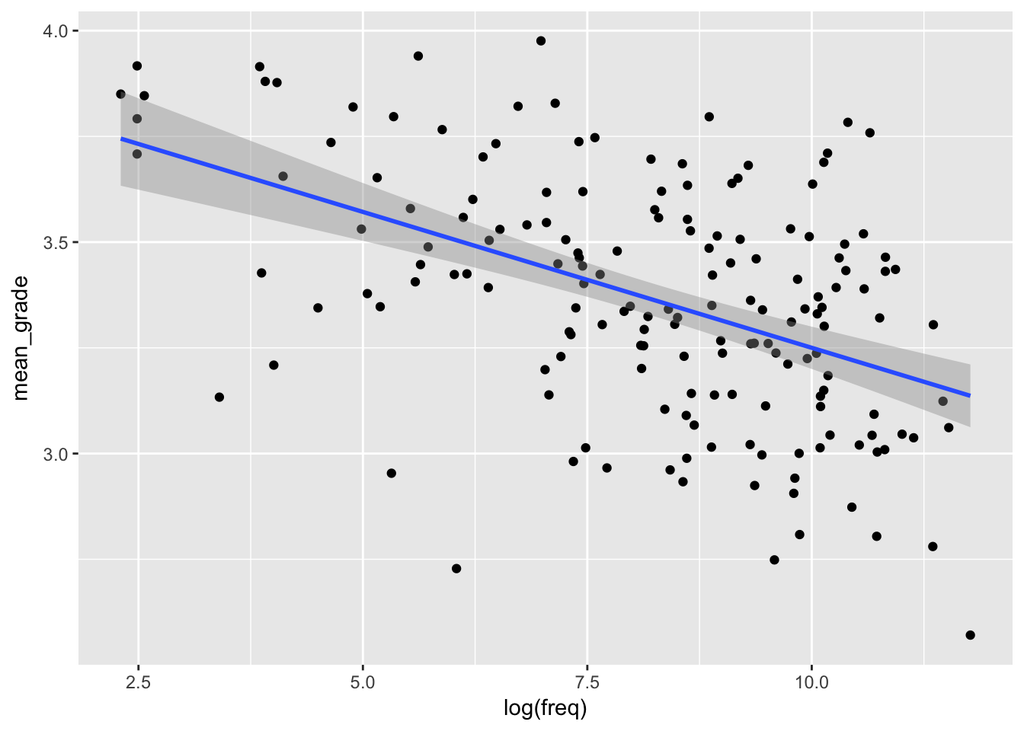

```r
gpas_by_subject %>%
  ggplot(aes(log(freq), mean_grade)) +
  geom_point() +
  geom_smooth(method = 'lm')
```

We can see a clear negative relationship between the quantity of students and the average grade awarded.

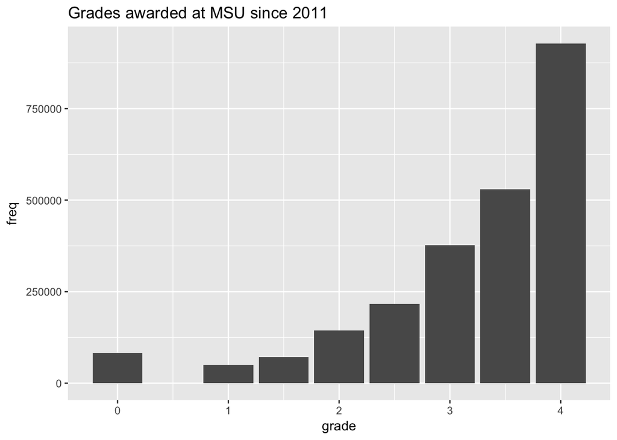

```r
tidy_grades %>%
  group_by(grade) %>%
  summarise(freq = sum(quantity)) %>%
  ggplot(aes(grade, freq)) +
  geom_histogram(stat = "identity") +
  ggtitle("Grades awarded at MSU since 2011")
```

## Trends over time

### Grade inflation

```r
tidy_grades_semester <- tidy_grades %>%
  # using rank to get the positional order of every semester)
  mutate(semester = dense_rank(tidy_grades$sortable_term)) %>%
  group_by(subject_code, semester) %>%
  summarise(mean_grade = sum(grade*quantity)/sum(quantity))
```

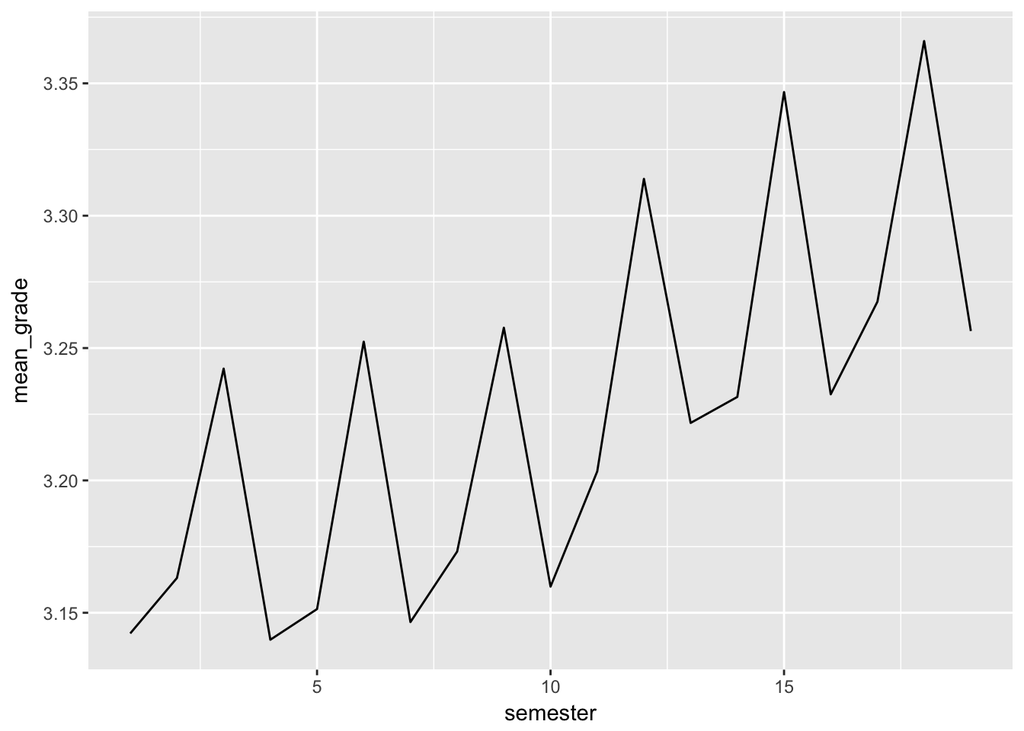

```r
tidy_grades %>%
  # using rank to get the positional order of every semester)
  mutate(semester = dense_rank(tidy_grades$sortable_term)) %>%
  group_by(semester) %>%
  summarise(mean_grade = sum(grade*quantity)/sum(quantity)) %>%
  ggplot(aes(semester, mean_grade)) +
  geom_line()
```

Two things - clear grade inflation and seasonaility at MSU. The peaks are summer semesters, which isn’t surprising. A lot of “fluff” or “blow off” classes are offered online over the summer. What I do find interesting is that spring (Jan - May) semesters tend to be consistently easier than fall semesters (Aug - Dec). Let’s split this up by season.

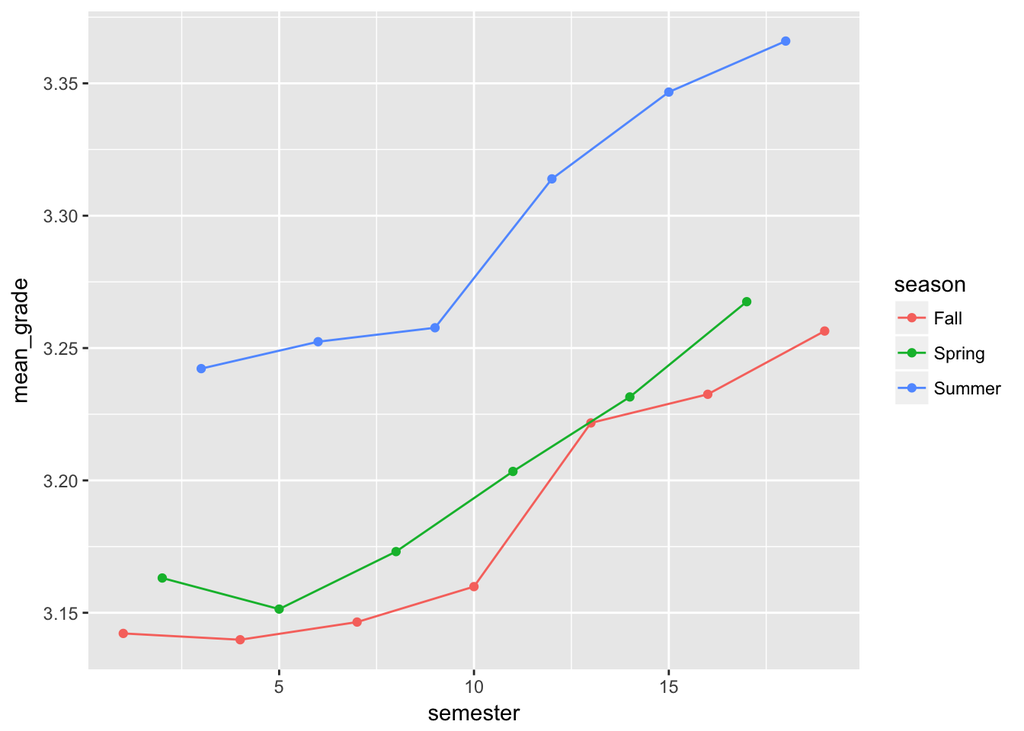

```r
tidy_grades_season <- tidy_grades %>%
  # using rank to get the positional order of every semester)
  mutate(semester = dense_rank(tidy_grades$sortable_term),
         season = str_sub(term_code, 1,1),
         season = ifelse(season == "F", "Fall",
                         ifelse(season == "S", "Spring",
                                ifelse(season == "U", "Summer", NA))
                         )
         )

tidy_grades_season %>%
  group_by(semester, season) %>%
  summarise(mean_grade = sum(grade*quantity)/sum(quantity)) %>%
  ggplot(aes(semester, mean_grade, color = season)) +
  geom_point() +
  geom_line()
```

```r
library("broom")

by_semester_subject <- tidy_grades_season %>%
  group_by(semester, subject_code, subject_name) %>%
  summarise(mean_grade = sum(grade*quantity)/sum(quantity))

sem_sub_slopes <- by_semester_subject %>%
  ungroup() %>%
  filter(!is.na(mean_grade)) %>%
  nest(-subject_code, -subject_name) %>%
  mutate(models = map(data, ~ lm(mean_grade ~ semester, .))) %>%
  mutate(tidied = map(models, tidy)) %>%
  unnest(tidied)

sem_sub_slopes
```

```
## # A tibble: 329 x 7
##    subject_code               subject_name        term     estimate
##           <chr>                      <chr>       <chr>        <dbl>
##  1          ABM    Agribusiness Management (Intercept)  2.827239122
##  2          ABM    Agribusiness Management    semester  0.011020537
##  3          ACC                 Accounting (Intercept)  2.913574110
##  4          ACC                 Accounting    semester  0.009301030
##  5          ACR  Comm Ag Rec & Res Studies (Intercept)  3.429859418
##  6          ACR  Comm Ag Rec & Res Studies    semester  0.027613059
##  7          ADV                Advertising (Intercept)  3.372543178
##  8          ADV                Advertising    semester -0.005983216
##  9           AE   Agricultural Engineering (Intercept)  3.228258303
## 10           AE   Agricultural Engineering    semester -0.021493529
## # ... with 319 more rows, and 3 more variables: std.error <dbl>,
## #   statistic <dbl>, p.value <dbl>
```

Most inflated

```r
inflated_5 <- sem_sub_slopes %>%
  filter(term == "semester") %>%
  arrange(desc(estimate)) %>%
  head(5)

inflated_5
```

```
## # A tibble: 5 x 7
##   subject_code                   subject_name     term   estimate
##          <chr>                          <chr>    <chr>      <dbl>
## 1          SME   Science & Math Ed (see MTHE) semester 0.33700441
## 2          CSP  Cosponsored Study Abroad Prog semester 0.06014492
## 3         ECSP   Economics Summer Bridge Prog semester 0.03819444
## 4         IBIO            Integrative Biology semester 0.03531626
## 5          PRR        Park, Rec & Tourism Res semester 0.03304580
## # ... with 3 more variables: std.error <dbl>, statistic <dbl>,
## #   p.value <dbl>
```

Most tom-brady-ed

```r
deflated_5 <- sem_sub_slopes %>%
  filter(term == "semester") %>%
  arrange(estimate) %>%
  head(5)

deflated_5
```

```
## # A tibble: 5 x 7
##   subject_code                   subject_name     term    estimate
##          <chr>                          <chr>    <chr>       <dbl>
## 1          CLA              Classical Studies semester -0.28042328
## 2          FLT      Foreign Language Teaching semester -0.04424906
## 3          TSM  Technology Systems Management semester -0.03033149
## 4          NEU                   Neuroscience semester -0.02957172
## 5         AESC   Applied Engineering Sciences semester -0.02862446
## # ... with 3 more variables: std.error <dbl>, statistic <dbl>,
## #   p.value <dbl>
```

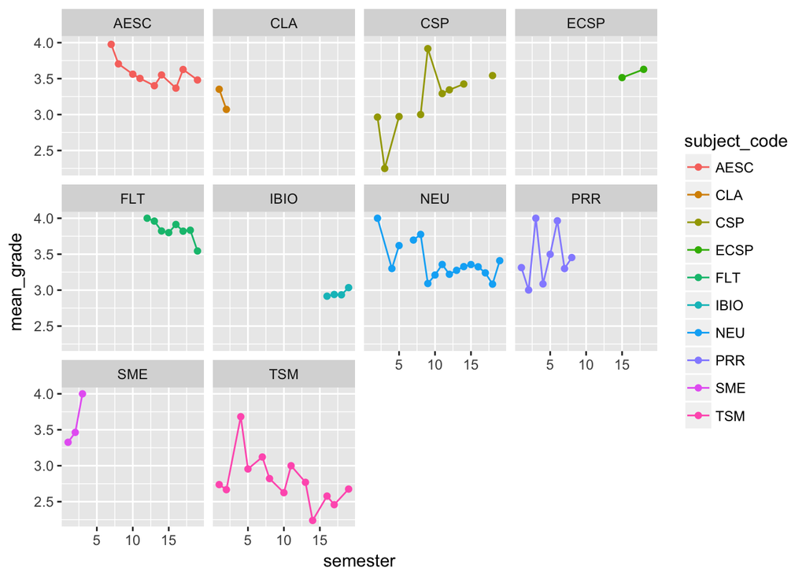

```r
by_semester_subject %>%
  filter(subject_code %in%
           c(inflated_5$subject_code, deflated_5$subject_code)) %>%
  ggplot(aes(semester, mean_grade, color = subject_code)) +
  geom_point() +
  geom_line() +
  facet_wrap(~subject_code)
```